# Assignment 2

Name:LIYING DENG

```r
library(dplyr)
library(data.table)
library(ggplot2)
```

# Part 1

Part 1- Question 1 After merging the data, make sure you don’t have any duplicates by counting the number of rows. Make sure it matches. In the case of missing values, impute data using the average amongst individuals with the same values for the “male” and “hispanic” variables. For categorical variables, take the mode. If you are interested (and feel adventurous) in the theme of Data Imputation, take a look at this paper on “Multiple Imputation” using the Amelia R package here.

```r
library(dplyr)
library(data.table)
library(tidyverse)
individual_data <- data.table::fread("/Users/kristydeng/Downloads/chs_individual.csv")
regional_data <- data.table::fread("/Users/kristydeng/Downloads/chs_regional.csv")
combined_data <- merge(individual_data, regional_data, by = "townname")
nrow(combined_data)
```

```
[1] 1200
```

```r
duplicated_rows <- combined_data[duplicated(combined_data), ]
combined_data <- combined_data[!duplicated(combined_data), ]
numeric_cols <- c("agepft", "height", "weight", "bmi", "fev", "fvc", "mmef", "pm2_5_fr", "no_24hr")
categorical_cols <- c("asthma", "active_asthma", "father_asthma", "mother_asthma",
                      "wheeze", "hayfever", "allergy", "educ_parent", "smoke",
                      "pets", "gasstove")
mode_function <- function(x) {
  ux <- unique(x)
  ux[which.max(tabulate(match(x, ux)))]
}
combined_data <- combined_data %>%
  group_by(male, hispanic) %>%
  mutate(across(where(~ all(. %in% c(0,1,2,3,4,5,NA))),
           ~ ifelse(is.na(.), mode_function(.), .)),
         across(where(is.numeric), ~ ifelse(is.na(.), mean(., na.rm = TRUE), .))
         )
```

Part 1 - Question 2 Create a new categorical variable named “obesity_level” using the BMI measurement (underweight BMI<14; normal BMI 14-22; overweight BMI 22-24; obese BMI>24). To make sure the variable is rightly coded, create a summary table that contains the minimum BMI, maximum BMI, and the total number of observations per category.

```r
library(dplyr)
combined_data <- combined_data %>%
  mutate(obesity_level = case_when(
    bmi < 14 ~ "underweight",
    bmi >= 14 & bmi <= 22 ~ "normal",
    bmi > 22 & bmi <= 24 ~ "overweight",
    bmi > 24 ~ "obese",
    TRUE ~ NA_character_
  ))
obesity_summary <- combined_data %>%
  group_by(obesity_level) %>%
  summarise(
    min_bmi = ifelse(all(is.na(bmi)), NA, min(bmi, na.rm = TRUE)),
    max_bmi = ifelse(all(is.na(bmi)), NA, max(bmi, na.rm = TRUE)),
    total_obs = n()
  )
print(obesity_summary)
```

```
# A tibble: 4 × 4
  obesity_level min_bmi max_bmi total_obs
  <chr>           <dbl>   <dbl>     <int>
1 normal           14.0    22.0       975
2 obese            24.0    41.3       103
3 overweight       22.0    24.0        87
4 underweight      11.3    14.0        35
```

Part 1 - Question 3 Create another categorical variable named “smoke_gas_exposure” that summarizes “Second Hand Smoke” and “Gas Stove.” The variable should have four categories in total.

```r
combined_data <- combined_data %>%
  mutate(smoke_gas_exposure = case_when(
    `smoke` == 0 & `gasstove` == 0 ~ "Neither",
    `smoke` == 1 & `gasstove` == 0 ~ "Only Second-Hand Smoke",
    `smoke` == 0 & `gasstove` == 1 ~ "Only Gas Stove",
    `smoke` == 1 & `gasstove` == 1 ~ "Both",
    TRUE ~ NA_character_
  ))
table(combined_data$smoke_gas_exposure)
```

```
                  Both                Neither         Only Gas Stove
                   154                    219                    791
Only Second-Hand Smoke
                    36
```

Part 1 - Question 4 Create four summary tables showing the average (or proportion, if binary) and sd of “Forced expiratory volume in 1 second (ml)” (an asthma indicator) by town, sex, obesity level, and “smoke_gas_exposure.”

```r
library(dplyr)
# 1. Summary table by town
summary_by_town <- combined_data %>%
  group_by(townname) %>%  # Replace 'townname' with the actual column name for town
  summarise(
    mean_fev = mean(fev, na.rm = TRUE),
    sd_fev = sd(fev, na.rm = TRUE),
  )
# 2. Summary table by sex
summary_by_sex <- combined_data %>%
  group_by(male) %>%  # Replace 'sex' with the actual column name for sex
  summarise(
    mean_fev = mean(fev, na.rm = TRUE),
    sd_fev = sd(fev, na.rm = TRUE),
    total_obs = n()
  )
# 3. Summary table by obesity level
summary_by_obesity <- combined_data %>%
  group_by(obesity_level) %>%  # Ensure the 'obesity_level' variable has been created
  summarise(
    mean_fev = mean(fev, na.rm = TRUE),
    sd_fev = sd(fev, na.rm = TRUE),
    total_obs = n()
  )
# 4. Summary table by smoke_gas_exposure
summary_by_smoke_gas_exposure <- combined_data %>%
  group_by(smoke_gas_exposure) %>%
  summarise(
    mean_fev = mean(fev, na.rm = TRUE),
    sd_fev = sd(fev, na.rm = TRUE),
    total_obs = n()
  )
summary_by_town
```

```
# A tibble: 12 × 3
   townname      mean_fev sd_fev
   <chr>            <dbl>  <dbl>
 1 Alpine           2087.   291.
 2 Atascadero       2076.   324.
 3 Lake Elsinore    2039.   304.
 4 Lake Gregory     2085.   320.
 5 Lancaster        2003.   317.
 6 Lompoc           2034.   351.
 7 Long Beach       1986.   319.
 8 Mira Loma        1985.   325.
 9 Riverside        1990.   278.
10 San Dimas        2027.   319.
11 Santa Maria      2026.   312.
12 Upland           2024.   343.
```

```r
summary_by_sex
```

```
# A tibble: 2 × 4
   male mean_fev sd_fev total_obs
  <int>    <dbl>  <dbl>     <int>
1     0    1959.   312.       610
2     1    2104.   308.       590
```

```r
summary_by_obesity
```

```
# A tibble: 4 × 4
  obesity_level mean_fev sd_fev total_obs
  <chr>            <dbl>  <dbl>     <int>
1 normal           2000.   295.       975
2 obese            2266.   325.       103
3 overweight       2224.   317.        87
4 underweight      1698.   303.        35
```

```r
summary_by_smoke_gas_exposure
```

```
# A tibble: 4 × 4
  smoke_gas_exposure     mean_fev sd_fev total_obs
  <chr>                     <dbl>  <dbl>     <int>
1 Both                      2025.   301.       154
2 Neither                   2057.   329.       219
3 Only Gas Stove            2023.   319.       791
4 Only Second-Hand Smoke    2056.   296.        36
```

# Part 2 - Looking at the Data (EDA)

What is the association between BMI and FEV (forced expiratory volume)?

```r
model <- lm(fev ~ bmi, data = combined_data)
summary(model)
```

```
Call:
lm(formula = fev ~ bmi, data = combined_data)

Residuals:
    Min      1Q  Median      3Q     Max
-989.47 -193.88  -11.32  179.43 1305.46

Coefficients:
            Estimate Std. Error t value Pr(>|t|)
(Intercept)  1452.46      44.49   32.65   <2e-16 ***
bmi            31.23       2.36   13.23   <2e-16 ***
---
Signif. codes:  0 '***' 0.001 '**' 0.01 '*' 0.05 '.' 0.1 ' ' 1

Residual standard error: 297.2 on 1198 degrees of freedom
Multiple R-squared:  0.1275,    Adjusted R-squared:  0.1268
F-statistic: 175.1 on 1 and 1198 DF,  p-value: < 2.2e-16
```

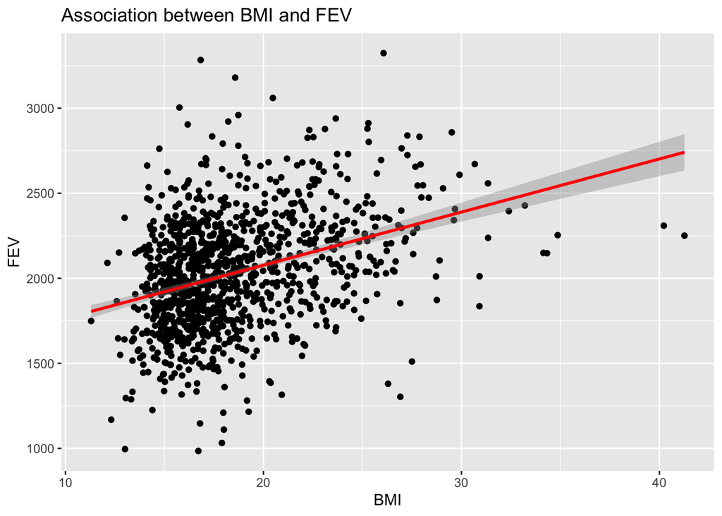

```r
ggplot(combined_data, aes(x = bmi, y = fev)) +
  geom_point() +
  geom_smooth(method = "lm", col = "Red") +
  labs(title = "Association between BMI and FEV", x = "BMI", y = "FEV")
```

```r
model <- lm(fev ~ bmi, data = combined_data)
summary(model)
```

```
Call:
lm(formula = fev ~ bmi, data = combined_data)

Residuals:
    Min      1Q  Median      3Q     Max
-989.47 -193.88  -11.32  179.43 1305.46

Coefficients:
            Estimate Std. Error t value Pr(>|t|)
(Intercept)  1452.46      44.49   32.65   <2e-16 ***
bmi            31.23       2.36   13.23   <2e-16 ***
---
Signif. codes:  0 '***' 0.001 '**' 0.01 '*' 0.05 '.' 0.1 ' ' 1

Residual standard error: 297.2 on 1198 degrees of freedom
Multiple R-squared:  0.1275,    Adjusted R-squared:  0.1268
F-statistic: 175.1 on 1 and 1198 DF,  p-value: < 2.2e-16
```

###Conclusion: P value less than 0.05, BMI has a significant positive association with FEV.

What is the association between smoke and gas exposure and FEV?

```r
anova_model <- aov(fev ~ smoke_gas_exposure, data = combined_data)
summary(anova_model)
```

```
                     Df    Sum Sq Mean Sq F value Pr(>F)
smoke_gas_exposure    3    226515   75505   0.746  0.525
Residuals          1196 121017980  101186
```

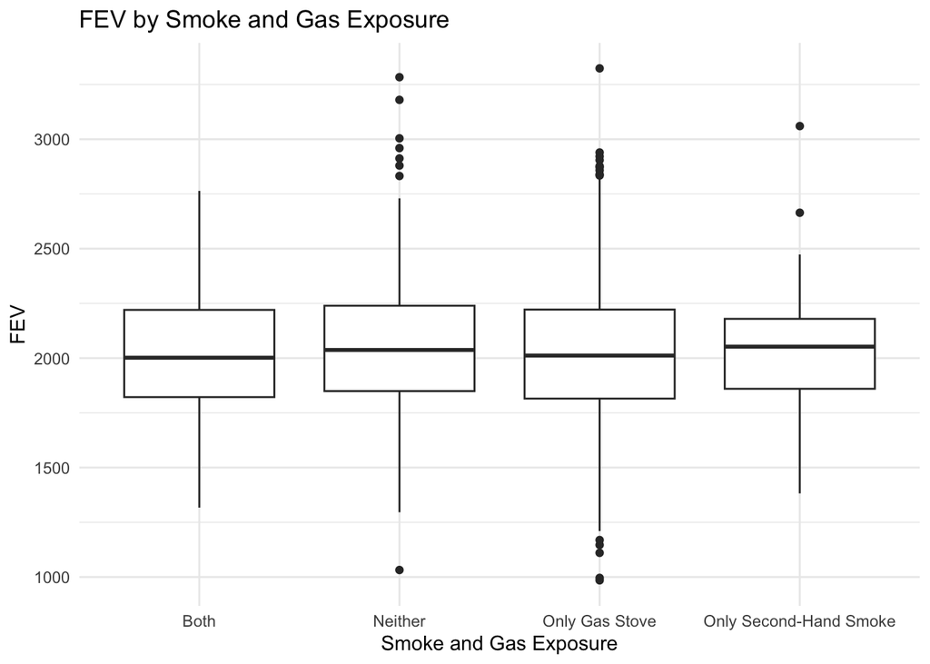

```r
ggplot(combined_data, aes(x = smoke_gas_exposure, y = fev)) +
  geom_boxplot() +
  labs(title = "FEV by Smoke and Gas Exposure", x = "Smoke and Gas Exposure", y = "FEV") +
  theme_minimal()
```

###Conclusion: The ANOVA test shows that there is no statistically significant association between smoke and gas exposure and FEV (p = 0.525).

What is the association between PM2.5 exposure and FEV?

```r
  summary_pm25_fev <- combined_data %>%
  summarise(
    mean_pm25 = mean(pm25_mass, na.rm = TRUE),
    mean_fev = mean(fev, na.rm = TRUE),
    sd_fev = sd(fev, na.rm = TRUE)
  )
pm25_fev_model <- lm(fev ~ pm25_mass, data = combined_data)
summary(pm25_fev_model)
```

```
Call:
lm(formula = fev ~ pm25_mass, data = combined_data)

Residuals:
     Min       1Q   Median       3Q      Max
-1070.63  -206.57   -13.33   195.87  1277.65

Coefficients:
            Estimate Std. Error t value Pr(>|t|)
(Intercept) 2073.452     19.309 107.383   <2e-16 ***
pm25_mass     -3.016      1.184  -2.548    0.011 *
---
Signif. codes:  0 '***' 0.001 '**' 0.01 '*' 0.05 '.' 0.1 ' ' 1

Residual standard error: 317.3 on 1198 degrees of freedom
Multiple R-squared:  0.005389,  Adjusted R-squared:  0.004559
F-statistic: 6.492 on 1 and 1198 DF,  p-value: 0.01096
```

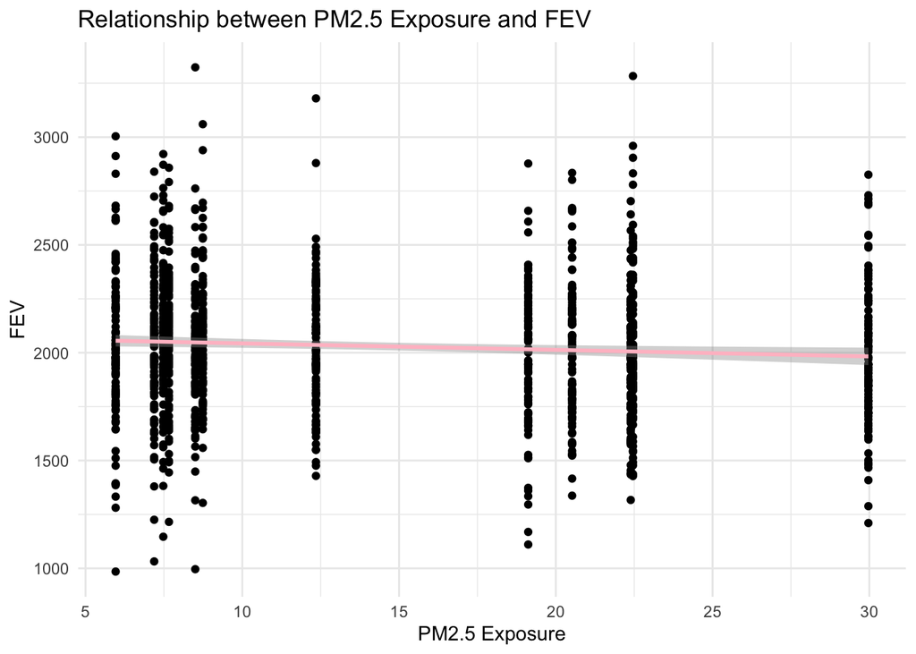

```r
ggplot(combined_data, aes(x = pm25_mass, y = fev)) +
  geom_point() +
  geom_smooth(method = "lm", col = "pink") +
  labs(title = "Relationship between PM2.5 Exposure and FEV",
       x = "PM2.5 Exposure",
       y = "FEV") +
  theme_minimal()
```

###Conclusion:P value less than 0.05, there is a significant negative association between PM2.5 exposure and FEV （P=0.01096)

# Part 3 Visualization

Facet plot showing scatterplots with regression lines of BMI vs FEV by “townname”

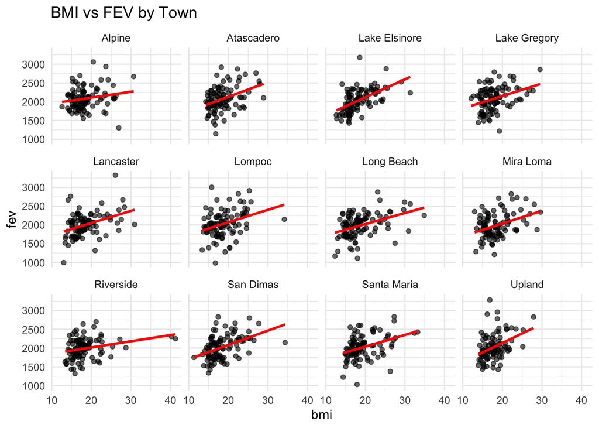

```r
library(ggplot2)
ggplot(combined_data, aes(x = bmi, y = fev)) +
  geom_point(alpha = 0.6) +
  geom_smooth(method = "lm", se = FALSE, color = "red") +
  facet_wrap(~ townname) +
  labs(title = "BMI vs FEV by Town", x = "bmi", y = "fev") +
  theme_minimal()
```

###Interpret: There is a positive association between BMI and FEV. As BMI increases, FEV also increase because many of the towns (like Alpine, Lancaster, Long Beach, Riverside, San Dimas,etc.) there is a positive slope.

Stacked histograms of FEV by BMI category and FEV by smoke/gas exposure

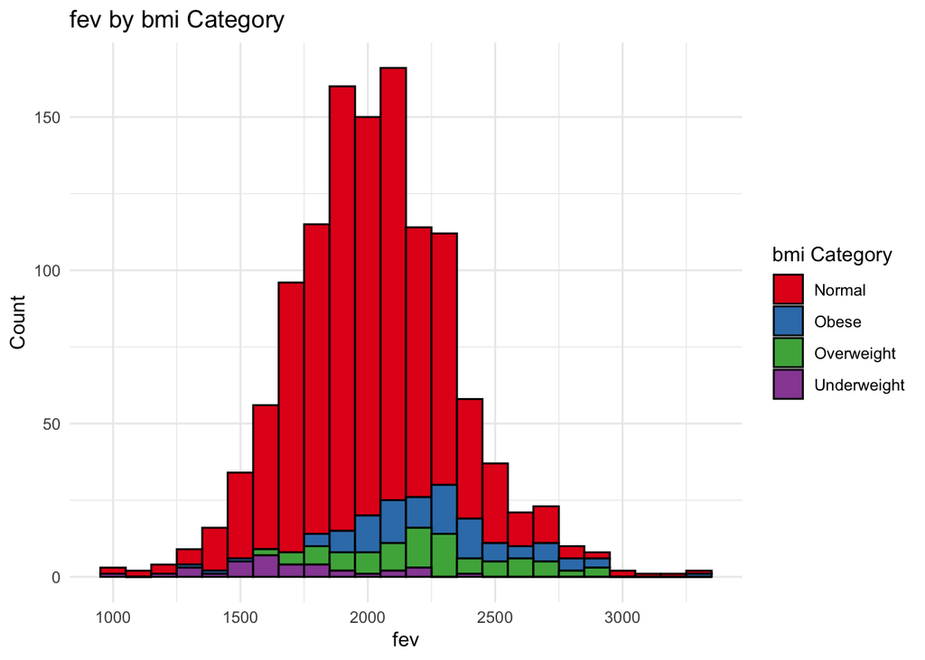

```r
library(ggplot2)
combined_data <- combined_data %>%
  mutate(bmi_category = case_when(
    bmi < 14 ~ "Underweight",
    bmi >= 14 & bmi <= 22 ~ "Normal",
    bmi > 22 & bmi <= 24 ~ "Overweight",
    bmi > 24 ~ "Obese"
  ))
ggplot(combined_data, aes(x = fev, fill = bmi_category)) +
  geom_histogram(position = "stack", binwidth = 100, color = "black") +
  scale_fill_brewer(palette = "Set1") +  # Use a different color scheme
  labs(title = "fev by bmi Category", x = "fev", y = "Count", fill = "bmi Category") +
  theme_minimal()
```

###Interpret：The distribution follows a bell-shaped curve (normal distribution). BMI individuals peaking around 2000 ml FEV. Obese and overweight individuals tend to have slightly higher FEV values, while underweight individuals mostly have lower FEV values.

Stacked histograms of FEV by smoke/gas exposure

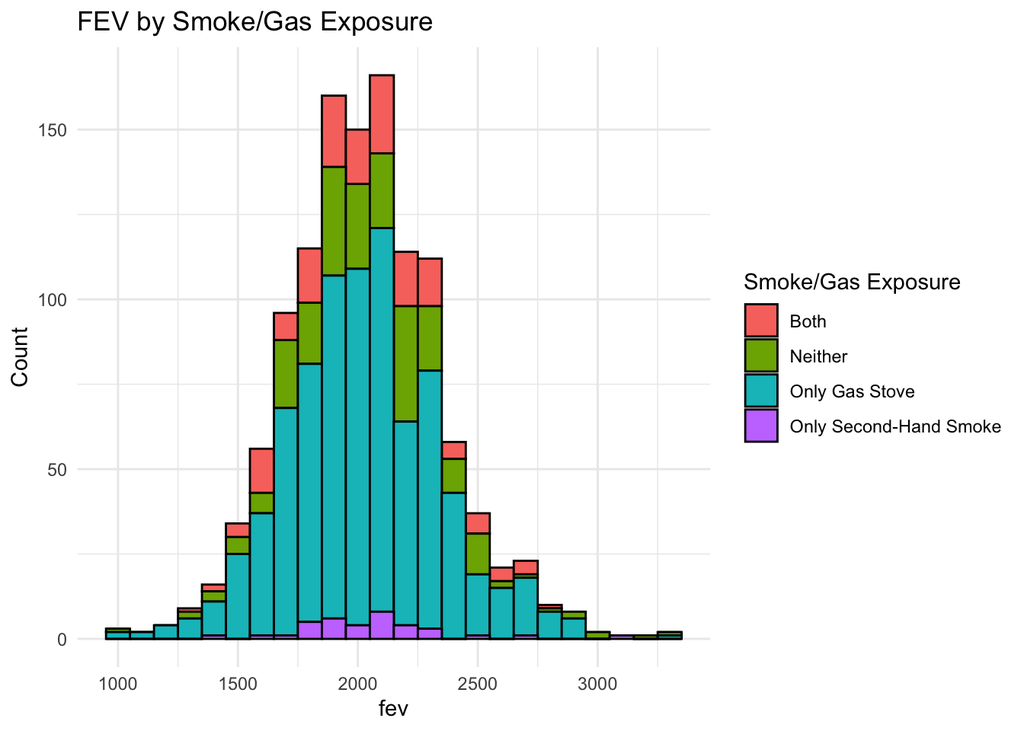

```r
ggplot(combined_data, aes(x = fev, fill = smoke_gas_exposure)) +
  geom_histogram(position = "stack", binwidth = 100, color = "black") +
  labs(title = "FEV by Smoke/Gas Exposure", x = "fev", y = "Count", fill = "Smoke/Gas Exposure") +
  theme_minimal()
```

Barchart of BMI by smoke/gas exposure

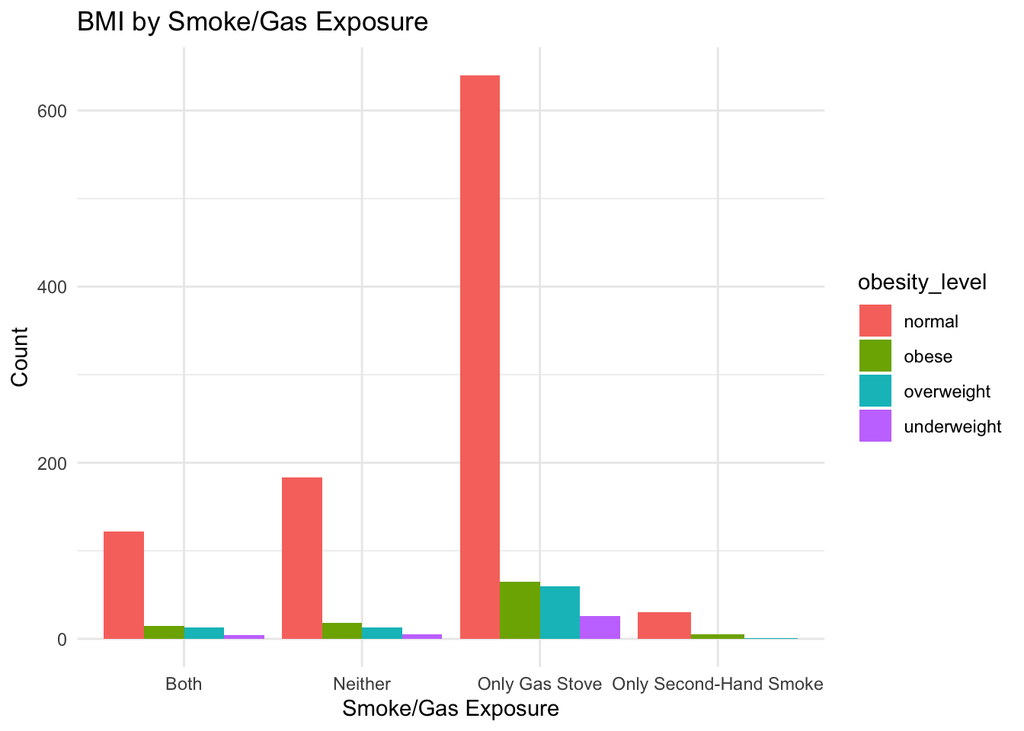

```r
ggplot(combined_data, aes(x = smoke_gas_exposure, fill = obesity_level)) +
  geom_bar(position ="dodge") +
  labs(title = "BMI by Smoke/Gas Exposure", x = "Smoke/Gas Exposure", y = "Count") +
  theme_minimal()
```

###Interpret: normal BMI are the most prevalent across all smoke/gas exposure categories, particularly in the Only Gas Stove and Neither groups. While there is representation of both overweight and obese individuals in each category, their numbers are smaller compared to those in the normal BMI group.

Statistical summary graphs of FEV by BMI

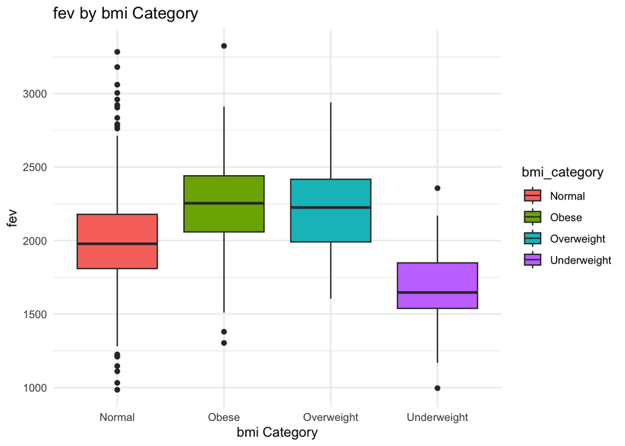

```r
ggplot(combined_data, aes(x = bmi_category, y = fev, fill = bmi_category)) +
  geom_boxplot() +
  labs(title = "fev by bmi Category", x = "bmi Category", y = "fev") +
  theme_minimal()
```

###Interpret:The boxplot suggests that individuals in the obese and overweight categories tend to have higher median FEV values compared to those in the normal and underweight groups. The boxplots for FEV by BMI and smoke/gas exposure visually summarize the variability across different groups, with clear indicators of the central tendency (median) and spread (interquartile range)

Statistical summary graphs of FEV by Smoke/Gas Exposure

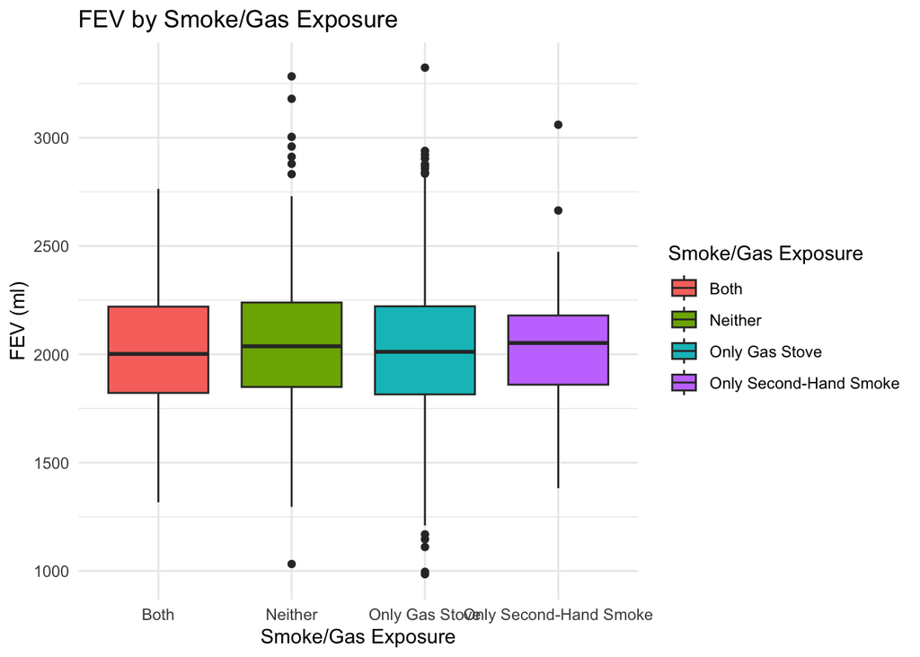

```r
ggplot(combined_data, aes(x = smoke_gas_exposure, y = fev, fill = smoke_gas_exposure)) +
  geom_boxplot() +
  labs(title = "FEV by Smoke/Gas Exposure", x = "Smoke/Gas Exposure", y = "FEV (ml)", fill = "Smoke/Gas Exposure") +
  theme_minimal()
```

A leaflet map showing the concentrations of PM2.5 mass in each of the CHS communities

```r
library(leaflet)
pal <- colorNumeric(palette = c("green", "pink", "blue"), domain = combined_data$pm25_mass)
leaflet(combined_data) %>%
  addTiles() %>%
  addCircleMarkers(
    ~lon, ~lat,
    radius = ~pm25_mass/3,
    color = ~pal(pm25_mass),
    stroke = FALSE, fillOpacity = 0.5,
    label = ~paste("Town:", townname, "<br>PM2.5:", pm25_mass)
  ) %>%
  addLegend(
    position = "bottomright",
    title = "PM2.5 Concentration",
    pal = pal,
    values = ~pm25_mass
  )
```

[interactive chart not shown]

###Interpret:The colored circles represent different levels of PM2.5 concentrations, with the size and color indicating the intensity of the pollution, Green represents lower levels of PM2.5 concentration, Pink represents moderate levels of PM2.5 concentration, Blue represents higher levels of PM2.5 concentration.Larger and darker circles (like blue) indicate the town of Mira Lowa higher concentrations of PM2.5 value reaches 29.97.

## Scatterplot of PM2.5 mass vs FEV

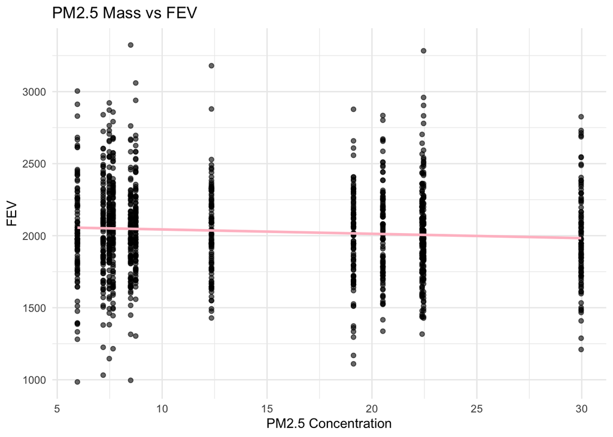

```r
ggplot(combined_data, aes(x = pm25_mass, y = fev)) +
  geom_point(alpha = 0.6) +
  geom_smooth(method = "lm", se = FALSE, color = "pink") +
  labs(title = "PM2.5 Mass vs FEV", x = "PM2.5 Concentration", y = "FEV") +
  theme_minimal()
```

###Interpret: there is a negative association between PM2.5 mass and FEV because the pink line shows the negative trends slope.